# Multiverse Analysis

Author

Alex Liebscher

Published

July 30, 2022

## Loading Libraries

```r
library(pacman)
p_load(tidyverse, janitor, magrittr, multiverse, marginaleffects)
```

## Loading the Data

Same as `dataset-descriptives.qmd`.

```r
data <- read_csv(
  "data.csv",
  show_col_types = F
) %>%
  clean_names()
```

Later on we’ll choose to examine our model with age as a categorical variable, so we’ll create that option here:

```r
data <- data %>%
  mutate(age_bin = case_when(
    age < 25 ~ "<25",
    age < 45 ~ "<45",
    age < 65 ~ "<65",
    T ~ ">=65",
  ))
```

## Multiverse Analysis

```r
IVs <- formula(". ~ greenspace_use_duration + nature_view +
        sex + age + age_bin +
        income + housing_type + impact_of_covid_19_on_income +
        frequency_of_smoking + frequency_of_drinking_alcohol +
        number_of_working_days + number_of_children + presence_of_a_pet")
```

### Build the Multiverse

Some resources I leaned on to learn about and create this multiverse analysis:

- http://www.the100.ci/2021/03/07/mulltiverse-analysis/
- https://journals.sagepub.com/doi/10.1177/1745691616658637

And a couple to help guide with marginal effects:

- https://www.andrewheiss.com/blog/2022/05/20/marginalia/#what-about-marginal-things-in-statistics
- https://vincentarelbundock.github.io/marginaleffects/articles/marginaleffects.html

Now, let’s create our multiverse:

```r
M = multiverse()
inside(M, {
  df = data
})
```

According to our conditional logic, we’ll establish different branches that our analysis could take. Again, our intention is to calculate our results for a variety of “arbitrary” modeling decisions.

```r
inside(M, {
  df = df %>%
    filter(branch(
      EXHT,
      "no_exc" ~ T,
      "housing_type_other" ~ housing_type != "other"
    )) %>%
    filter(branch(
      FTW,
      "all" ~ T,
      "full_time_only" ~ number_of_working_days >= 5
    ))
})

inside(M, {
  predictors <- branch(
    CN,
    "greenspace_use_only" ~ update.formula(IVs, . ~ . - nature_view),
    "greenspace_use_nature_view" ~ IVs
  )

  predictors <- branch(
    GSL,
    "identity" ~ predictors,
    "log" ~ update.formula(predictors, . ~ . - greenspace_use_duration + log(greenspace_use_duration+1))
  )

  predictors <- branch(
    AB,
    "num" ~ update.formula(predictors, . ~ . - age_bin),
    "bin" ~ update.formula(predictors, . ~ . - age)
  )

  predictors <- branch(
    DP,
    "exc" ~ update.formula(predictors, . ~ . - age - age_bin - sex),
    "inc" ~ predictors
  )

  predictors <- branch(
    IP,
    "exc" ~ update.formula(predictors, . ~ . - income - impact_of_covid_19_on_income),
    "inc" ~ predictors
  )

  predictors <- branch(
    ILP,
    "identity" %when% (IP == "inc") ~ predictors,
    "log" %when% (IP == "inc") ~ update.formula(predictors, . ~ . - income + log(income)),
    "none" ~ predictors
  )

  predictors <- branch(
    LP,
    "exc" ~ update.formula(predictors, . ~ . - housing_type -
        frequency_of_smoking - frequency_of_drinking_alcohol -
        number_of_working_days - number_of_children - presence_of_a_pet),
    "inc" ~ predictors
  )
})
```

Next, we’ll fit our linear models on our five measures of mental health:

```r
inside(M, {
  model.loneliness <- lm(
    update.formula(predictors, loneliness ~ .),
    data = df
  )

  model.depression_and_anxiety <- lm(
    update.formula(predictors, depression_and_anxiety ~ .),
    data = df
  )

  model.life_satisfaction <- lm(
    update.formula(predictors, life_satisfaction ~ .),
    data = df
  )

  model.self_esteem <- lm(
    update.formula(predictors, self_esteem ~ .),
    data = df
  )

  model.subjective_happiness <- lm(
    update.formula(predictors, subjective_happiness ~ .),
    data = df
  )
})
```

Lastly, we calculate marginal effects for each DV of our Greenspace Use predictor. We do this because we’re interested in the effect of Greenspace Use on mental health.

```r
inside(M, {
  mfx.loneliness <- model.loneliness %>%
    marginaleffects(variables = "greenspace_use_duration") %>%
    tidy()

  mfx.depression_and_anxiety <- model.depression_and_anxiety %>%
    marginaleffects(variables = "greenspace_use_duration") %>%
    tidy()

  mfx.life_satisfaction <- model.life_satisfaction %>%
    marginaleffects(variables = "greenspace_use_duration") %>%
    tidy()

  mfx.self_esteem <- model.self_esteem %>%
    marginaleffects(variables = "greenspace_use_duration") %>%
    tidy()

  mfx.subjective_happiness <- model.subjective_happiness %>%
    marginaleffects(variables = "greenspace_use_duration") %>%
    tidy()
})
```

### Execute the Multiverse

The `multiverse` package makes it very simple to execute each of these many universes of analyses:

```r
execute_multiverse(M)
```

### Visualization

To top it all off, we’ll create some visualizations of our results. First we need to create useable data:

```r
expand_multiverse_results <- function(var) {
  expand(M) %>%
    extract_variables({{var}}) %>%
    unnest(cols = c({{var}})) %>%
    select(-c(.parameter_assignment, .code, .results, .errors, type))
}

multiverse_results_loneliness <- expand_multiverse_results("mfx.loneliness")
multiverse_results_depression_and_anxiety <- expand_multiverse_results("mfx.depression_and_anxiety")
multiverse_results_life_satisfaction <- expand_multiverse_results("mfx.life_satisfaction")
multiverse_results_self_esteem <- expand_multiverse_results("mfx.self_esteem")
multiverse_results_subjective_happiness <- expand_multiverse_results("mfx.subjective_happiness")
```

```r
universes <- bind_rows(
  multiverse_results_loneliness %>%
    mutate(dv = "Loneliness"),
  multiverse_results_depression_and_anxiety %>%
    mutate(dv = "Depression and Anxiety"),
  multiverse_results_life_satisfaction %>%
    mutate(dv = "Life Satisfaction"),
  multiverse_results_self_esteem %>%
    mutate(dv = "Self-Esteem"),
  multiverse_results_subjective_happiness %>%
    mutate(dv = "Happiness")
)
```

Now we plot our Average Marginal Effects (AME) of Greenspace Use for each DV:

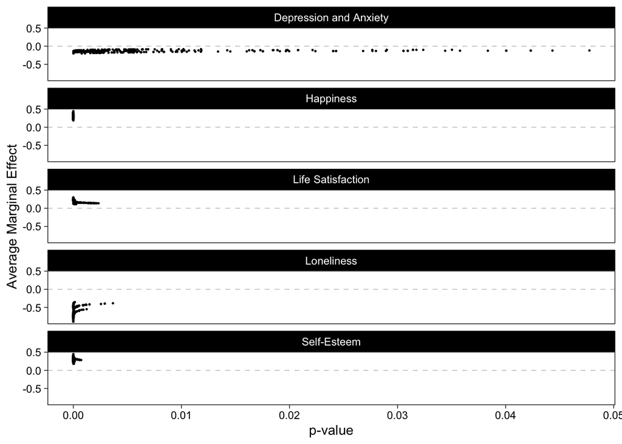

```r
universes %>%
  ggplot(aes(p.value, estimate)) +
  geom_point(size = 0.25) +
  geom_hline(yintercept = 0, size = 0.25, color = "grey", linetype = "dashed") +
  facet_wrap(~ dv, ncol = 1, scales = "fixed") +
  labs(x = "p-value", y = "Average Marginal Effect") +
  theme_linedraw() +
  theme(panel.grid = element_blank())
```

Lastly, specification curves for our DVs:

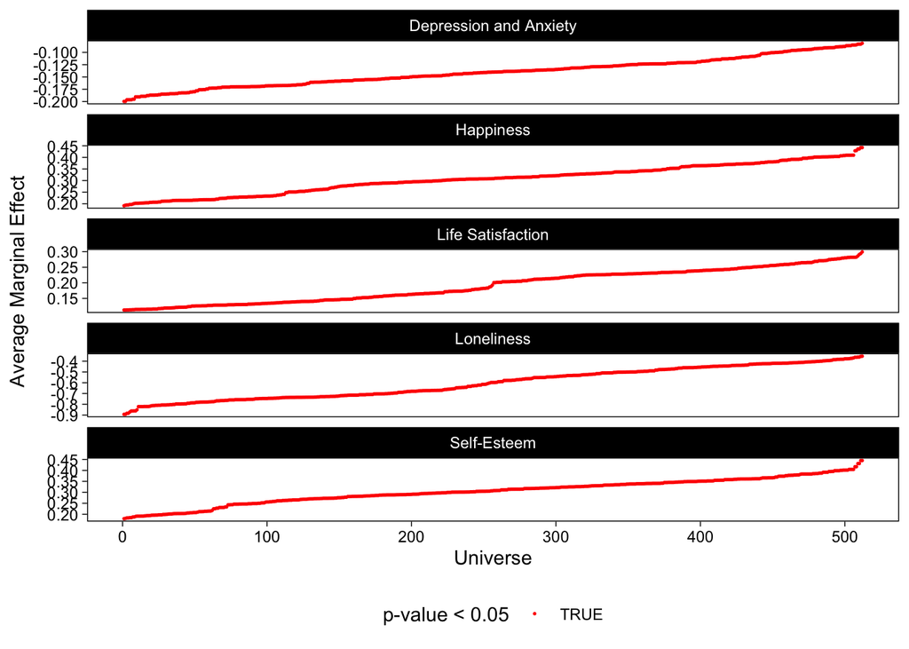

```r
universes %>%
  group_by(dv) %>%
  arrange(estimate) %>%
  mutate(.universe = 1:n()) %>%
  ggplot(aes(.universe, estimate)) +
  geom_point(aes(color = p.value < 0.05), size = 0.25) +
  scale_color_manual(values = c("red", "blue")) +
  facet_wrap(~ dv, ncol = 1, scales = "free_y") +
  labs(x = "Universe", y = "Average Marginal Effect", color = "p-value < 0.05") +
  theme_linedraw() +
  theme(panel.grid = element_blank(), legend.position = "bottom")
```